# books

The Assignment for Week 5 - Data Visualisation with Python

```python
!pip install pandas matplotlib numpy
```

```python
import pandas as pd
df= pd.read_csv("Books.csv")
df
```

|  | Title | Author | Genre | Pages | Rating (Goodreads) | Year |
| --- | --- | --- | --- | --- | --- | --- |
| 0 | Atomic Habits | Džeims Klīrs | self-help | 320 | 4.33 | 2018 |
| 1 | Harry Potter and the Order of the Phoenix | J. K. Rowling | fantasy | 870 | 4.50 | 2003 |
| 2 | Anime: A History | Jonathan Clements | fim criticism | 256 | 4.16 | 2013 |
| 3 | The Little Book of Ikigai | Ken Mogi | self-help | 112 | 3.58 | 2017 |
| 4 | Lugu lendavate taldrikutega | Eno Raud | children's books | 240 | 4.09 | 1969 |
| 5 | Roosad inglid | Reeli Reinaus | young adult | 211 | 3.45 | 2014 |
| 6 | Verikambi | Reeli Reinaus | young adult | 352 | 4.09 | 2016 |
| 7 | Little Women | Louisa May Alcott | feminism | 449 | 4.17 | 1868 |
| 8 | The Yellow Wall-paper | Charlotte Perkins Gilman | feminism | 62 | 4.07 | 1892 |
| 9 | Crime and Punishment | Fyodor Dostoyevsky | philosophy | 671 | 4.28 | 1866 |
| 10 | Pride and Predjudice | Jane Austen | romance | 400 | 4.29 | 1813 |
| 11 | A Silent Voice, Vol. 1 | Yoshitoki Oima | manga | 190 | 4.46 | 2013 |
| 12 | Blue Period 1 | Tsubasa Yamaguchi | manga | 224 | 4.40 | 2017 |
| 13 | Emma | Jane Austen | romance | 474 | 4.05 | 1815 |
| 14 | The Vegan Guide to Tokyo | Chiara Terzuolo | nonfiction | 160 | 4.21 | 2023 |
| 15 | Carrie | Stephen King | horror | 272 | 3.99 | 1974 |
| 16 | All the Bright Places | Jennifer Niven | young adult | 388 | 4.11 | 2015 |
| 17 | Elevant haihtub | Haruki Murakami | fantasy | 327 | 3.82 | 1993 |
| 18 | IT | Stephen King | horror | 1184 | 4.24 | 1968 |
| 19 | Joyland | Stephen King | horror | 285 | 3.93 | 2013 |
| 20 | The Queen's Gambit | Walter Tevis | historical | 258 | 4.18 | 1983 |
| 21 | Euphoria | Elin Cullhed | feminism | 304 | 3.51 | 2021 |
| 22 | Inter Ice Age 4 | Kobo Abe | sci-fi | 228 | 3.68 | 1959 |
| 23 | Citizen: An American Lyric | Claudia Rankine | poetry | 169 | 4.25 | 2014 |
| 24 | The Tales of Beetle the Bard | J. K. Rowling | fantasy | 105 | 4.03 | 2008 |

```python
df.describe() # generate some statistics
```

|  | Pages | Rating (Goodreads) | Year |
| --- | --- | --- | --- |
| count | 25.000000 | 25.000000 | 25.000000 |
| mean | 340.440000 | 4.074800 | 1972.200000 |
| std | 248.599926 | 0.281338 | 66.119211 |
| min | 62.000000 | 3.450000 | 1813.000000 |
| 25% | 211.000000 | 3.990000 | 1968.000000 |
| 50% | 272.000000 | 4.110000 | 2008.000000 |
| 75% | 388.000000 | 4.250000 | 2015.000000 |
| max | 1184.000000 | 4.500000 | 2023.000000 |

Column chart for book´s number of pages (average) and genre:

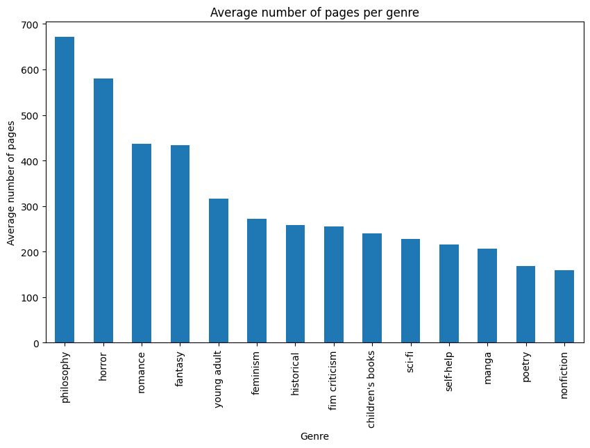

```python
import matplotlib.pyplot as plt
avg_pages=df.groupby("Genre")["Pages"].mean(). sort_values(ascending=False)
avg_pages.plot(kind="bar", figsize=(10, 6), x="Genre", y="Average number of pages")
total_avg = avg_pages.sum()
plt.ylabel("Average number of pages")
plt.title("Average number of pages per genre")
```

Biggest average number of pages is presented by the philosopy genre at 671 pages average. Smallest average number of pages is presented by the nonfiction genre at only 160 pages average.

Column chart for book´s scores on average per genre:

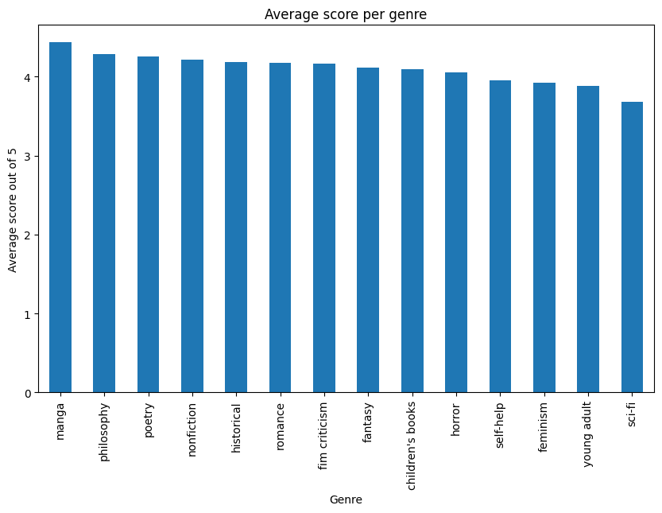

```python
avg_scores=df.groupby("Genre")["Rating (Goodreads)"].mean(). sort_values(ascending=False)
avg_scores.plot(kind="bar", figsize=(10, 6), x="Genre", y="Average score")
plt.title("Average score per genre")
plt.ylabel("Average score out of 5")
```

The biggest average score on Goodreads was for the books in the manga genre at 4.43 average. The smallest average score on Goodreads was for the books in the sci-fi genre at 3.68 average. Goodreads scores are between 0-5, 5 being the best.

Column chart for average score per author:

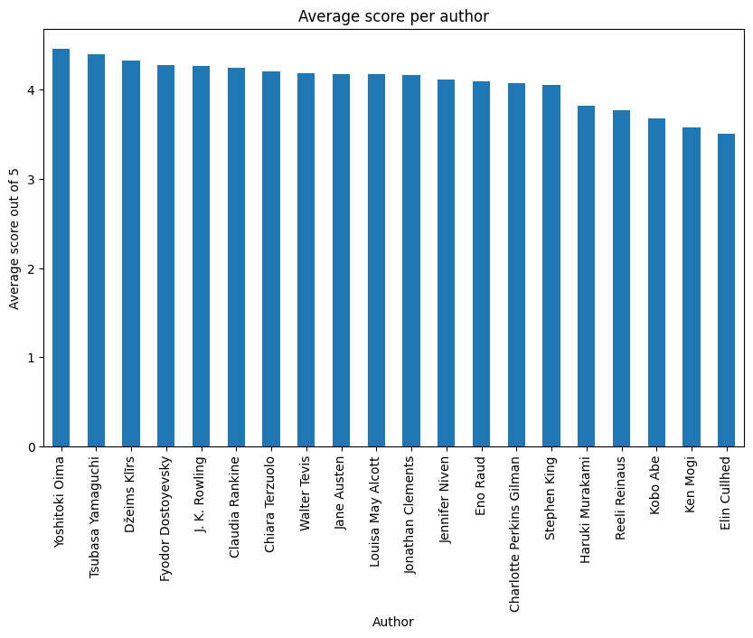

```python
avg_author=df.groupby("Author")["Rating (Goodreads)"].mean(). sort_values(ascending=False)
avg_author.plot(kind="bar", figsize=(10, 6), x="Author", y="Average score")
plt.title("Average score per author")
plt.ylabel("Average score out of 5")
```

Books written by author Yoshitoki Oima have the biggest average score by 4.46 average. Books written by author Elin Cullhed have the smallest average score by 3.51 average.

Pie chart for books sorted by author:

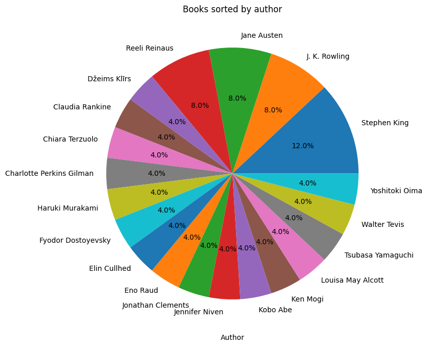

```python
count_books = df.groupby("Author")["Title"].count(). sort_values(ascending=False)
count_books.plot(kind="pie", figsize=(8, 8), autopct='%1.1f%%', legend=False)
plt.title("Books sorted by author")
plt.xlabel("Author")
plt.ylabel("")
```

Out of all the authors who's books were listed, Stephen King's books were more than any other authors, 3 books, which makes 12% out of all the books. A little bit less, but still more than most authos, J. K. Rowling, Jane Austen and Reeli Reinus each had 2 books presented, which makes each of these three authors 8% of all the books. Most of the authors had only one book presented in the list and therefore each authors books presents 4% of the books read. Because the difference between how many books by each author were listed (1-3 books per author), we can assume that I love books by a lot of different authors. But because Stephen King had 3 books in the list (the maximum abount), we can assume that I like his books the most or have the tendency to.

Pie chart for books sorted by genre:

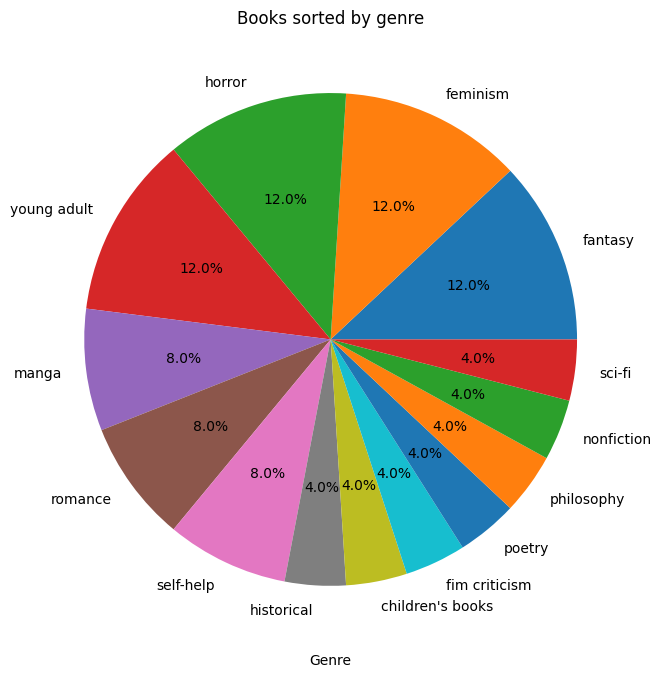

```python
count_booksgenre = df.groupby("Genre")["Title"].count(). sort_values(ascending=False)
count_booksgenre.plot(kind="pie", figsize=(8, 8), autopct='%1.1f%%', legend=False)
plt.title("Books sorted by genre")
plt.xlabel("Genre")
plt.ylabel("")
```

Scatter plot diagram for books according to page number and score:

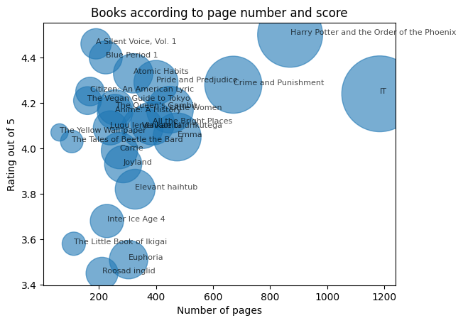

```python
plt.scatter(df["Pages"], df["Rating (Goodreads)"], s=df["Pages"]*5, alpha=0.6)
plt.xlabel("Number of pages")
plt.ylabel("Rating out of 5")
plt.title("Books according to page number and score")
for i in range(len(df)):
    plt.text(df["Pages"].iloc[i],
             df["Rating (Goodreads)"].iloc[i],
             df["Title"].iloc[i],
             fontsize=8, alpha=0.7)
```

The bubble chart shows that most of the books listed had a number of pages from 1-500 and had a score above 3. The three books that stand out and differ from the rest are Harry Potter and the Order of the Phoenix, IT and Crime and Punishment, as those three books were higher in number of pages (more than 500). Not one book stands out or differs from the other books by score. All books had a fairly similar score, above 3 at least. But we can count books in to two groups, 1. few of them with a score about 3.4-3.8, and 2. most of the books with a score about 3.8-4.5.

Box plot diagram for number of pages and year of release:

```
Minimum pages: 62 Q1: 211.0
```

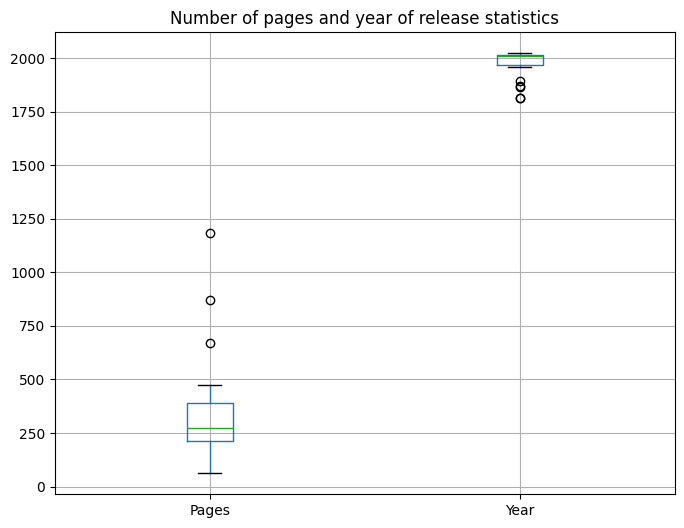

```python
#Calculate quartiles and extremes
pages_min = df["Pages"].min()
pages_q1 = df["Pages"].quantile(0.25)
print("Minimum pages:", pages_min, "Q1:", pages_q1)



#boxplot graph
plt.figure(figsize=(8,6))
df[["Pages", "Year"]].boxplot()
plt.title("Number of pages and year of release statistics")
plt.ylabel("")
```

The shortest book is The Yellow Wall-paper with 62 pages, the longest is IT by Stephen King with 1184 pages. 25% of the books are shorter than or equal to 211 pages. There is a wide range in page counts (62-1184). The chart shows that most books are between 200–400 pages, but few are significantly longer. The year of release ranges from 1813 (Pride and Prejudice) to 2023 (The Vegan Guide to Tokyo). That can mean, that for me the date or release is not so important and that I like to read books from modern and older times. Many of the books are published after 2000, suggesting that I more than often choose to read or have liked, or that bookstores put more books out that are published in the 21st century.